# Internal comparison experiment

Collin Erickson

January 20, 2019

We are going to run an experiment using our `SGGP` code to see how the various options affect the prediction ability of the model.

Internal options

- Selection method in append: UCB, TS, Greedy
- Correlation function: Cauchy, CauchySQ, CauchySQT, Gaussian, Power exponential, Matern 3/2, Matern 5/2
- Sampling method in fit: Laplace approx, MCMC
- Grid size: fast (1 2 4 4 4 6 8 32), slow (1 2 2 2 4 4 4 4 4 6 32)
- Batch size
- Prediction: use MAP, full Bayesian using samples
- Append blocks using RIMSE or RIMSE/point
- Point location

## Internal options for our experiment

- 3. Selection method: UCB, TS, Greedy
- 3. Corr func: CauchySQT, Gaussian, Power exp
- 2. Sampling method: Laplace, MCMC
- 2. Grid size: fast (1 2 4 4 4 6 8 32), slow (1 2 2 2 4 4 4 4 4 6 32)
- 2. Batch size: 64 or 256 up to 1024, then 512 for both
- 2. Prediction: MAP, full Bayesian
- 2. Append using RIMSE, RIMSE/point

This is $2^5 3^2 = 288$ options. We can do a fractional factorial experiment to save time.

## First experiment (Comparer2)

I saw that MCMC and full Bayesian prediction were far slower than their alternatives. I ran a smaller experiment on my computer with the following

- 3. Selection method: UCB, TS, Greedy
- 7. Corr func: CauchySQT, CauchySQ, Cauchy, Gaussian, Power exp, Matern 3/2, and Matern 5/2
- 1. Sampling method: Laplace, MCMC
- 2. Grid size: fast (1 2 4 4 4 6 8 32), slow (1 2 2 2 4 4 4 4 4 6 32)
- 2. Batch size: 64 or 256 up to 1024, then 512 for both
- 1. Prediction: MAP, full Bayesian
- 2. Append using RIMSE, RIMSE/point

This took over a day on my laptop using 3 cores.

```r
e2 <- readRDS("ComparerRun2_completed.rds")
```

```r
e2$completed_runs %>% table
```

```
## .
## TRUE
##  168
```

I look at the results and saw something weird going on. It turns out that some of the runs became awful after large number of points.

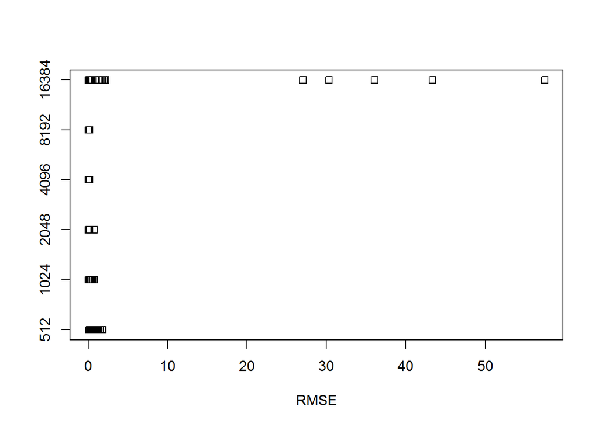

```r
stripchart(RMSE ~ nallotted, e2$outcleandf)
```

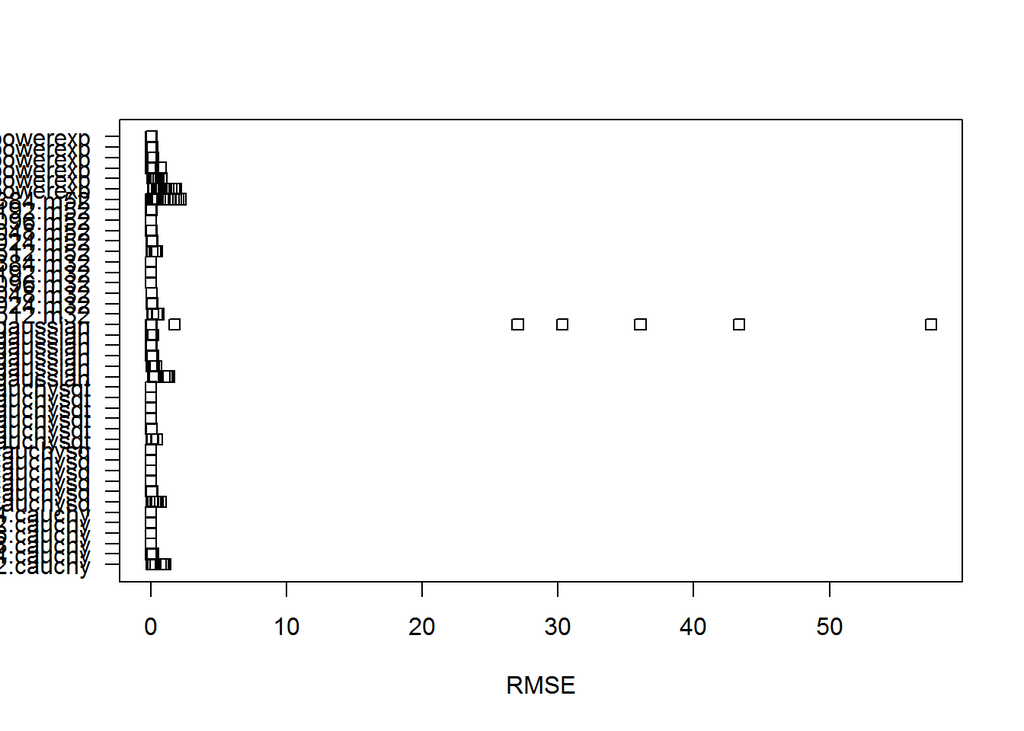

```r
stripchart(RMSE ~ nallotted + corr, e2$outcleandf, las=1)
```

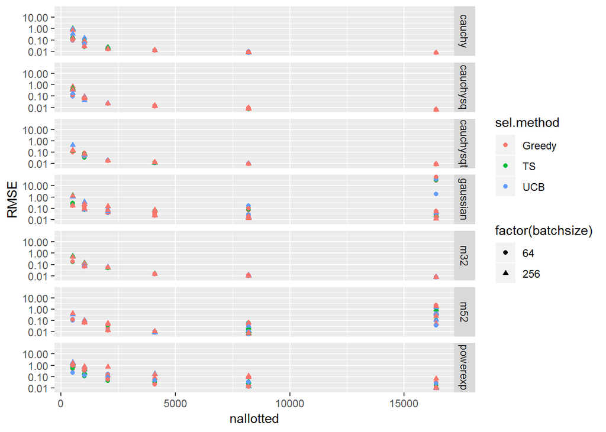

```r
ggplot(data=e2$outcleandf, mapping=aes(x=nallotted,y=RMSE, shape=factor(batchsize), color=sel.method)) + geom_point() +
  facet_grid(corr ~ .) + ggplot2::scale_y_log10()
```

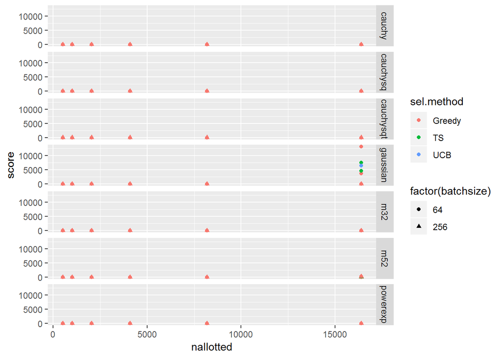

```r
ggplot(data=e2$outcleandf, mapping=aes(x=nallotted,y=score, shape=factor(batchsize), color=sel.method)) + geom_point() +
  facet_grid(corr ~ .)
```

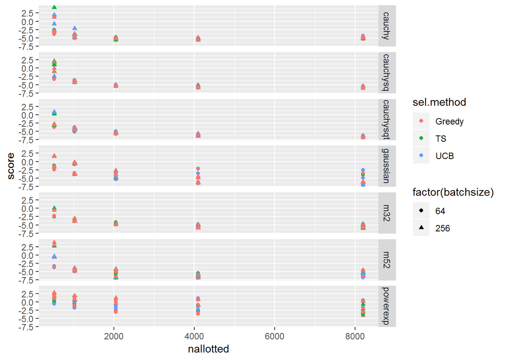

```r
ggplot(data=e2$outcleandf[e2$outcleandf$nallotted!=16384,], mapping=aes(x=nallotted,y=score, shape=factor(batchsize), color=sel.method)) + geom_point() +
  facet_grid(corr ~ .)
```